# Analyzing EPA PM2.5 Data

Example: San Bernardino County

Marc Los Huertos

March 10, 2025

Updated: 2025-03-10 21:53:15

# Introduction

Air qualily data varies seasonally, regionally, and with particular events. These create a distribution of values, some of which pose potential health effects.

## Goals

We will collect EPA air quality data to compare with the local data we collect to assses if our data fall within the confidence intervals of the EPA database.

## Rationale

By collecting and analyzing air quality data, we will be able to estimate the central tendencies of the data. With these estimates, we can determine if our sensor data fall within these estimates.

## Grading – Interactive Process, via Reflections

As an assignment with relatively low stakes, 10 points, you will be assessed using the following criteria:

1. Collect 10 years of PM2.5 AQI from one county in the USA.
2. Report the median, mean, standard deviation, and 95% confidence interval for each station.
3. Plot 10-years of data and create a threshold line based on state and federal standards for PM2.5. Please include the folowing:
- Rotated y-axis
- Appropriate axis labels
- Scatter plot with added EPA or state health limits.
- Estimate the mean, S.D. and 95% confidence intervals for each month.
- Using the peer reviewed literature, discuss the implications of the results. I suggest several (more than 2 and less than 9) peer reviewed articles and a few paragraphs (more than 1 and less than 4) discussion the regional causes and implications of the results.
4. Submit Rmd and pdf via Canvas.

# Procedures

## Accessing EPA Data

We will use the EPA website (https://www.epa.gov/outdoor-air-quality-data/air-data-multiyear-tile-plot) to collect the data. Select a location and download 10 years of data. You’ll get a “tile plot”, but at the bottom is a link to download the csv file.

## Upload to Rstudio Server Folder

First, create a folder on the Rstudio server to store the data. This will make it easier to manage the data and keep it organized.

Next, we’ll upload the data to Rstudio. After getting the data from the EPA downloaded, you can upload the data to R.

## Read Data

Create file path that points to the csv file.

```r
county = "San Bernardino"
san_bernardino.csv <- "/home/mwl04747/EJnPi/data/ad_viz_tile_data.csv"
```

Read the csv files into dataframes

```r
SB = read.csv(san_bernardino.csv)

# Remove 06-071-9010 and 06-071-9002
SB = subset(SB, Site.ID != "06-071-9010" & Site.ID != "06-071-9002")

# Remove Low Sampling Locations
# Evaluate N for each location
SB$Site.ID = as.character(SB$Site.ID)
SB.N = aggregate(PM2.5.AQI.Value ~ Site.ID, data=SB, length); SB.N
```

```
##       Site.ID PM2.5.AQI.Value
## 1 06-071-0005              96
## 2 06-071-0027            2241
## 3 06-071-0306             180
## 4 06-071-1004             802
## 5 06-071-2002             207
## 6 06-071-8001             146
## 7 06-071-9004              33
```

```r
# Which are these??

# Remove low sampling locations
```

[output not shown]

Always a good idea of checking what we created:

```r
str(SB)
```

```
## 'data.frame':    3705 obs. of  6 variables:
##  $ Date           : chr  "01/01/2015" "01/02/2015" "01/03/2015" "01/04/2015" ...
##  $ PM2.5.AQI.Value: int  84 88 112 93 57 70 57 62 106 125 ...
##  $ Main.Pollutant : logi  NA NA NA NA NA NA ...
##  $ Site.Name      : chr  "Ontario-Route 60 Near Road" "Ontario-Route 60 Near Road" "Ontario-Route 60 Near Road" "Ontario-Route 60 Near Road" ...
##  $ Site.ID        : chr  "06-071-0027" "06-071-0027" "06-071-0027" "06-071-0027" ...
##  $ Source         : chr  "AQS" "AQS" "AQS" "AQS" ...
```

## Fix Dates

As usually, we need to fix the data to make sure R can read them properly.

```r
Date.char = as.character(SB$Date)
# testing to make sure this works...
# as.Date(Date.char, format="%m/%d/%Y")
SB$Date = as.Date(Date.char, format="%m/%d/%Y")
```

Check to see if that worked:

```r
str(SB)
```

```
## 'data.frame':    3705 obs. of  6 variables:
##  $ Date           : Date, format: "2015-01-01" "2015-01-02" ...
##  $ PM2.5.AQI.Value: int  84 88 112 93 57 70 57 62 106 125 ...
##  $ Main.Pollutant : logi  NA NA NA NA NA NA ...
##  $ Site.Name      : chr  "Ontario-Route 60 Near Road" "Ontario-Route 60 Near Road" "Ontario-Route 60 Near Road" "Ontario-Route 60 Near Road" ...
##  $ Site.ID        : chr  "06-071-0027" "06-071-0027" "06-071-0027" "06-071-0027" ...
##  $ Source         : chr  "AQS" "AQS" "AQS" "AQS" ...
```

```r
names(SB)
```

```
## [1] "Date"            "PM2.5.AQI.Value" "Main.Pollutant"  "Site.Name"
## [5] "Site.ID"         "Source"
```

Okay, that seems to work. Noticed that I replaced the original date variable with the new one. I could have created a new variable, but I didn’t.

## Graphic Analysis

Now we will plot the data to see what it looks like. We will use the plot() function to create a scatter plot of the data.

### Box Plot of PM2.5 – A good evaluation tool

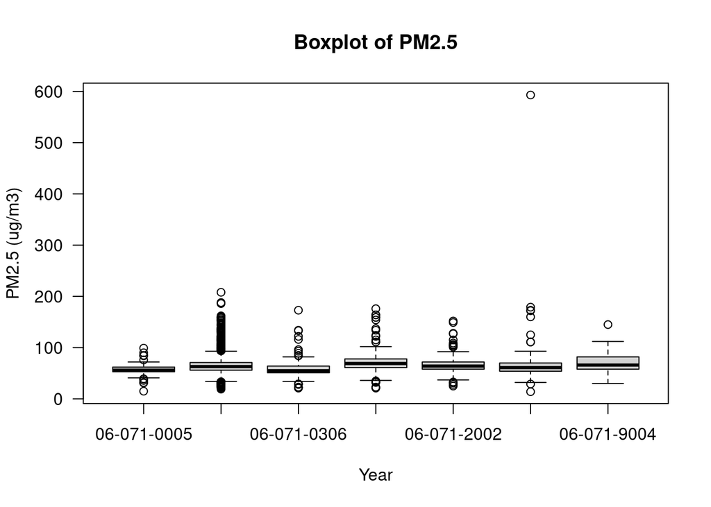

```r
par(las=1)
boxplot(PM2.5.AQI.Value ~ Site.ID, data=SB, main="Boxplot of PM2.5",
        ylab="PM2.5 (ug/m3)", xlab="Year")
```

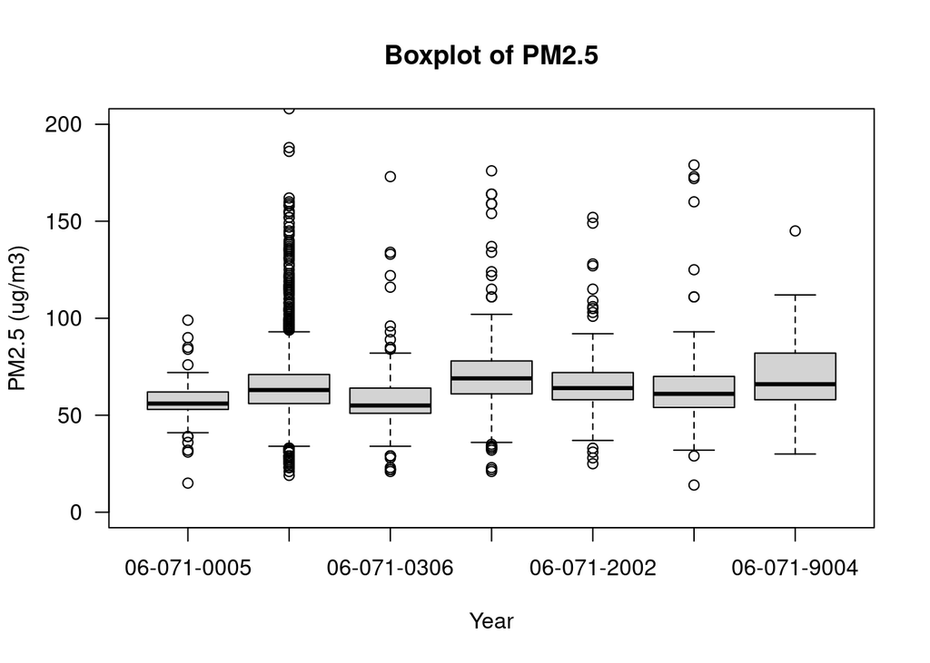

```r
par(las=1)
boxplot(PM2.5.AQI.Value ~ Site.ID, data=SB, main="Boxplot of PM2.5",
        ylab="PM2.5 (ug/m3)", xlab="Year", ylim=c(0,200))
```

### Names of Sites

```r
unique(SB$Site.Name)
```

```
## [1] "Ontario-Route 60 Near Road" "Big Bear"
## [3] "Upland"                     "Fontana"
## [5] "Crestline"                  "San Bernardino"
## [7] "Victorville-Park Avenue"
```

```r
SB.unique = unique(SB[c("Site.ID", "Site.Name")]); SB.unique
```

```
##         Site.ID                  Site.Name
## 1   06-071-0027 Ontario-Route 60 Near Road
## 6   06-071-8001                   Big Bear
## 8   06-071-1004                     Upland
## 9   06-071-2002                    Fontana
## 15  06-071-0005                  Crestline
## 45  06-071-9004             San Bernardino
## 401 06-071-0306    Victorville-Park Avenue
```

Rank them by median

```r
SB.median = aggregate(PM2.5.AQI.Value ~ Site.ID, data=SB, median)
SB.median
```

```
##       Site.ID PM2.5.AQI.Value
## 1 06-071-0005              56
## 2 06-071-0027              63
## 3 06-071-0306              55
## 4 06-071-1004              69
## 5 06-071-2002              64
## 6 06-071-8001              61
## 7 06-071-9004              66
```

```r
SB.median = merge(SB.median, SB.unique, by="Site.ID")
SB.median = SB.median[order(SB.median$`PM2.5.AQI.Value`),]; SB.median
```

```
##       Site.ID PM2.5.AQI.Value                  Site.Name
## 3 06-071-0306              55    Victorville-Park Avenue
## 1 06-071-0005              56                  Crestline
## 6 06-071-8001              61                   Big Bear
## 2 06-071-0027              63 Ontario-Route 60 Near Road
## 5 06-071-2002              64                    Fontana
## 7 06-071-9004              66             San Bernardino
## 4 06-071-1004              69                     Upland
```

### Scatter Plot of PM2.5

All the sites…

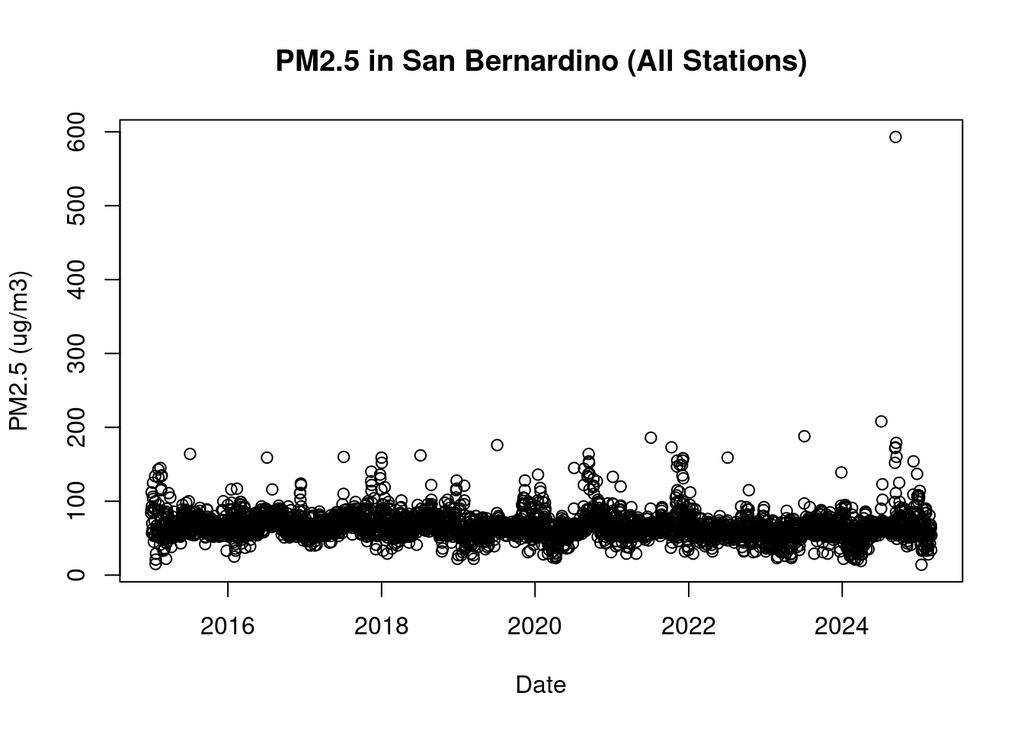

```r
plot(SB$Date, SB$PM2.5.AQI.Value, xlab="Date", ylab="PM2.5 (ug/m3)", main="PM2.5 in San Bernardino (All Stations)")
```

### Scatter Plot of PM2.5 by Date for each Site

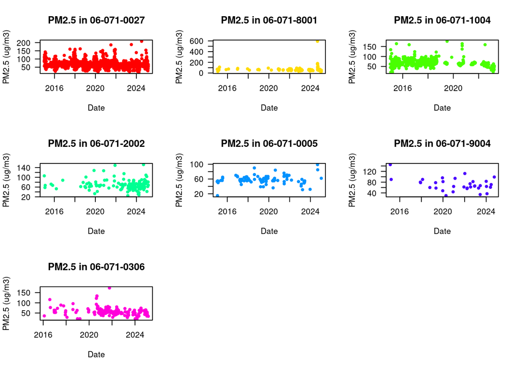

```r
par(las=1, mfrow=c(3,3))
for (i in 1:length(unique(SB$Site.ID))) {
  SB.subset=subset(SB, Site.ID==unique(SB$Site.ID)[i])
  plotcolor=rainbow(length(unique(SB$Site.ID)))[i]

  plot(PM2.5.AQI.Value ~ Date, SB.subset, xlab="Date", ylab="PM2.5 (ug/m3)", main=paste("PM2.5 in", unique(SB$Site.ID)[i]), pch=20, col=plotcolor)
}
```

### Scatter Plot of PM2.5 by Date for each Site

Remember the syntax plot(y~x, data=dataframe)! And you can use abline to put the EPA standard on there, abline(h=some value), where the line is a “horizontal line” that equals some value that you specify.

This is a good place to add the EPA standard for PM2.5, which is 35 ug/m3.

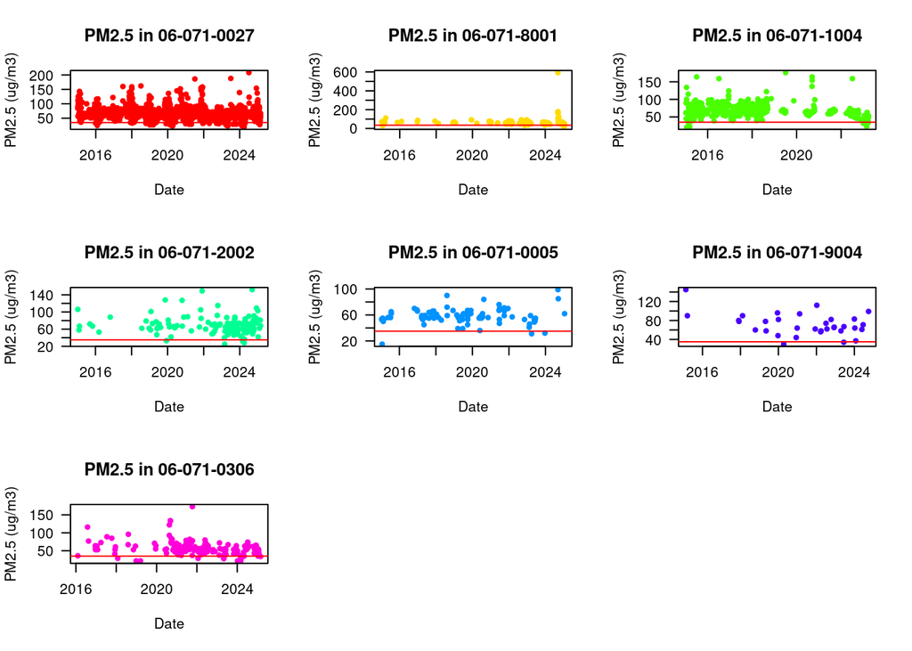

```r
par(las=1, mfrow=c(3,3))
for (i in 1:length(unique(SB$Site.ID))) {
  SB.subset=subset(SB, Site.ID==unique(SB$Site.ID)[i])
  plotcolor=rainbow(length(unique(SB$Site.ID)))[i]

  plot(PM2.5.AQI.Value ~ Date, SB.subset, xlab="Date", ylab="PM2.5 (ug/m3)", main=paste("PM2.5 in", unique(SB$Site.ID)[i]), pch=20, col=plotcolor)
  abline(h=35, col="red")
}
```

# Monthly Central Tendancy

Next we will determine the central tendency, e.g. median, mean, standard deviation.

So, we will use some packages or libraries to make our job easier. To add packages that are not installed be default, use the Packages tab and click on Install – and then search for dpylr and lubridate to install. NOTE: If you have some response that R needs to restart let me know, there is some bug for some installations not allowing the package to be installed correctly – but I didn’t have the problem, so we need to reach out to POM-ITS to sort it out (fun stuff).

the dplyr is described as ``a grammar of data manipulation, providing a consistent set of verbs that help you solve the most common data manipulation challenges.’’

The lubridate makes it easier manipulate date-times.

We call these libraries in the rcode as below.

```r
library(dplyr)
library(lubridate)
tmp1 <- mutate(SB, Date = ymd(Date),Year = year(Date), Month = month(Date))
tmp2 <- group_by(tmp1, Month, Year)

Monthly <- summarise(tmp2, result = mean(PM2.5.AQI.Value) )
## `summarise()` has grouped output by 'Month'. You can override using the
## `.groups` argument.
```

NOTE: R generates a warning. Seems like ignoring is just fine. Someday, I’ll figure out how to fix or suppress the warning.

```r
  Monthly <- SB %>%
  mutate(Date = ymd(Date),Year = year(Date), Month = month(Date)) %>%
  group_by(Month, Site.ID) %>%
  summarise(median = median(PM2.5.AQI.Value),
            mean = mean(PM2.5.AQI.Value),
            sd = sd(PM2.5.AQI.Value),
            N = length(PM2.5.AQI.Value) )
head(Monthly)
```

```
## # A tibble: 6 × 6
## # Groups:   Month [1]
##   Month Site.ID     median  mean    sd     N
##   <dbl> <chr>        <dbl> <dbl> <dbl> <int>
## 1     1 06-071-0005     54  50.3  16.0     7
## 2     1 06-071-0027     65  68.7  20.3   250
## 3     1 06-071-0306     47  44.3  12.0    14
## 4     1 06-071-1004     60  63    26.5    25
## 5     1 06-071-2002     72  71.9  25.9     7
## 6     1 06-071-8001     61  57.9  15.2    32
```

It’s takes a bit to get used to this grammar – frankly, I am still practicing!